# Prediction Assignment Writeup

I. Diaz, PEng.

2019-12-28

# Background

Using devices such as Jawbone Up, Nike FuelBand, and Fitbit it is now possible to collect a large amount of data about personal activity relatively inexpensively. These type of devices are part of the quantified self movement – a group of enthusiasts who take measurements about themselves regularly to improve their health, to find patterns in their behavior, or because they are tech geeks. One thing that people regularly do is quantify how much of a particular activity they do, but they rarely quantify how well they do it. In this project, your goal will be to use data from accelerometers on the belt, forearm, arm, and dumbell of 6 participants. They were asked to perform barbell lifts correctly and incorrectly in 5 different ways. More information is available from the website here: http://web.archive.org/web/20161224072740/http:/groupware.les.inf.puc-rio.br/har (see the section on the Weight Lifting Exercise Dataset).

# Data

The data for this project come from this source: http://web.archive.org/web/20161224072740/http:/groupware.les.inf.puc-rio.br/har. If you use the document you create for this class for any purpose please cite them as they have been very generous in allowing their data to be used for this kind of assignment.

Training: https://d396qusza40orc.cloudfront.net/predmachlearn/pml-training.csv Test: https://d396qusza40orc.cloudfront.net/predmachlearn/pml-testing.csv

# Development

## Getting and Wrangling Data

I’ll split training data into 70% to train the model, and remaining 30% to validate de model. The testing data in no used yet.

```r
# set the URL for the download
Url1 <- "http://d396qusza40orc.cloudfront.net/predmachlearn/pml-training.csv"
Url2  <- "http://d396qusza40orc.cloudfront.net/predmachlearn/pml-testing.csv"

# download the datasets
data_train <- read.csv(url(Url1))
data_test  <- read.csv(url(Url2))

# create a partition with the training dataset
split  <- createDataPartition(data_train$classe, p=0.7, list=FALSE)
training_set <- data_train[split, ]
testing_set  <- data_train[-for_train, ]
```

[output not shown]

[output not shown]

The training set is made of 13737 rows and 160 columns, many of them are NAs or empty cells. It’s necessary to remove them in order to have a tidy data.

#### Removing irrelevant data

The Near Zero variance (NZV) variables are also removed and the ID variables as well.

```r
NZV <- nearZeroVar(TrainSet)
TrainSet <- TrainSet[, -NZV]
TestSet  <- TestSet[, -NZV]
dim(TrainSet)
```

```
[1] 13737   107
```

```r
dim(TestSet)
```

```
[1] 5885  107
```

Next, NAs is going to be removed from training and testing data.

```r
AllNA    <- sapply(TrainSet, function(x) mean(is.na(x))) > 0.95
TrainSet <- TrainSet[, AllNA==FALSE]
TestSet  <- TestSet[, AllNA==FALSE]
dim(TrainSet)
```

```
[1] 13737    59
```

```r
dim(TestSet)
```

```
[1] 5885   59
```

Now, data is suppose to be cleaned but is steel necessary to remove the identification variables, those are not necessary to our development.

```r
TrainSet <- TrainSet[, -(1:5)]
TestSet  <- TestSet[, -(1:5)]
dim(TrainSet)
```

```
[1] 13737    54
```

```r
dim(TestSet)
```

```
[1] 5885   54
```

The cleaning process is completed.

## Exploratory Analysis

### Correlation

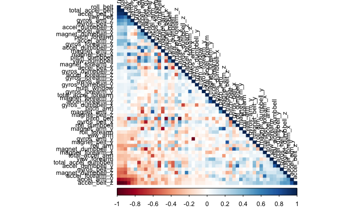

```r
corMatrix <- cor(TrainSet[, -54])
corrplot(corMatrix, order = "FPC", method = "color", type = "lower",
         tl.cex = 0.8, tl.col = rgb(0, 0, 0))
```

In the analysis performed above dark color in both sides means high correlation, direct or inverse.

## Building the Model

### Random Forest

```r
# fit the model
set.seed(12345)
controlRF <- trainControl(method="cv", number=3, verboseIter=FALSE)
modFitRandForest <- train(classe ~ ., data=TrainSet, method="rf",
                          trControl=controlRF)
modFitRandForest$finalModel
```

```
Call:
 randomForest(x = x, y = y, mtry = param$mtry)
               Type of random forest: classification
                     Number of trees: 500
No. of variables tried at each split: 27

        OOB estimate of  error rate: 0.3%
Confusion matrix:
     A    B    C    D    E  class.error
A 3904    2    0    0    0 0.0005120328
B    8 2646    3    1    0 0.0045146727
C    0    9 2386    1    0 0.0041736227
D    0    0   11 2240    1 0.0053285968
E    0    0    0    5 2520 0.0019801980
```

```r
# prediction on Test dataset
predictRandForest <- predict(modFitRandForest, newdata=TestSet)
confMatRandForest <- confusionMatrix(predictRandForest, TestSet$classe)
confMatRandForest
```

```
Confusion Matrix and Statistics

          Reference
Prediction    A    B    C    D    E
         A 1672    4    0    0    0
         B    1 1135    8    0    0
         C    0    0 1017    2    0
         D    0    0    1  962    1
         E    1    0    0    0 1081

Overall Statistics

               Accuracy : 0.9969
                 95% CI : (0.9952, 0.9982)
    No Information Rate : 0.2845
    P-Value [Acc > NIR] : < 2.2e-16

                  Kappa : 0.9961

 Mcnemar's Test P-Value : NA

Statistics by Class:

                     Class: A Class: B Class: C Class: D Class: E
Sensitivity            0.9988   0.9965   0.9912   0.9979   0.9991
Specificity            0.9991   0.9981   0.9996   0.9996   0.9998
Pos Pred Value         0.9976   0.9921   0.9980   0.9979   0.9991
Neg Pred Value         0.9995   0.9992   0.9982   0.9996   0.9998
Prevalence             0.2845   0.1935   0.1743   0.1638   0.1839
Detection Rate         0.2841   0.1929   0.1728   0.1635   0.1837
Detection Prevalence   0.2848   0.1944   0.1732   0.1638   0.1839
Balanced Accuracy      0.9989   0.9973   0.9954   0.9988   0.9994
```

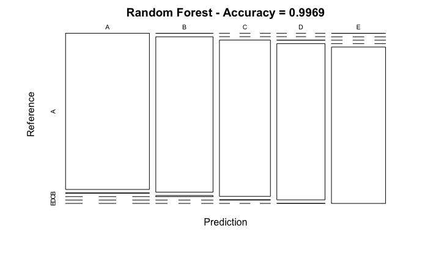

```r
# plot matrix results
plot(confMatRandForest$table, col = confMatRandForest$byClass,
     main = paste("Random Forest - Accuracy =",
                  round(confMatRandForest$overall['Accuracy'], 4)))
```

[figure not shown]

### Desicion Trees

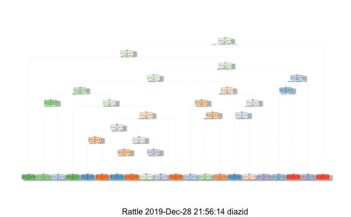

```r
# model fit
set.seed(12345)
modFitDecTree <- rpart(classe ~ ., data=TrainSet, method="class")
fancyRpartPlot(modFitDecTree)
```

```r
# prediction on Test dataset
predictDecTree <- predict(modFitDecTree, newdata=TestSet, type="class")
confMatDecTree <- confusionMatrix(predictDecTree, TestSet$classe)
confMatDecTree
```

```
Confusion Matrix and Statistics

          Reference
Prediction    A    B    C    D    E
         A 1493  213   44   64   66
         B   55  670   48   71  115
         C   10   55  810  133   71
         D   88  144   57  643  139
         E   28   57   67   53  691

Overall Statistics

               Accuracy : 0.7319
                 95% CI : (0.7203, 0.7431)
    No Information Rate : 0.2845
    P-Value [Acc > NIR] : < 2.2e-16

                  Kappa : 0.6596

 Mcnemar's Test P-Value : < 2.2e-16

Statistics by Class:

                     Class: A Class: B Class: C Class: D Class: E
Sensitivity            0.8919   0.5882   0.7895   0.6670   0.6386
Specificity            0.9081   0.9391   0.9446   0.9130   0.9573
Pos Pred Value         0.7941   0.6986   0.7507   0.6004   0.7712
Neg Pred Value         0.9548   0.9048   0.9551   0.9333   0.9216
Prevalence             0.2845   0.1935   0.1743   0.1638   0.1839
Detection Rate         0.2537   0.1138   0.1376   0.1093   0.1174
Detection Prevalence   0.3195   0.1630   0.1833   0.1820   0.1523
Balanced Accuracy      0.9000   0.7637   0.8671   0.7900   0.7980
```

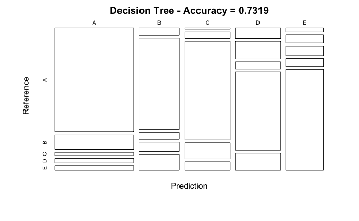

```r
# plot matrix results
plot(confMatDecTree$table, col = confMatDecTree$byClass,
     main = paste("Decision Tree - Accuracy =",
                  round(confMatDecTree$overall['Accuracy'], 4)))
```

### Generalized Boosted Model

```r
set.seed(12345)
controlGBM <- trainControl(method = "repeatedcv", number = 5, repeats = 1)
modFitGBM  <- train(classe ~ ., data=TrainSet, method = "gbm",
                    trControl = controlGBM, verbose = FALSE)
modFitGBM$finalModel
```

```
A gradient boosted model with multinomial loss function.
150 iterations were performed.
There were 53 predictors of which 53 had non-zero influence.
```

```r
# prediction on Test dataset
predictGBM <- predict(modFitGBM, newdata=TestSet)
confMatGBM <- confusionMatrix(predictGBM, TestSet$classe)
confMatGBM
```

```
Confusion Matrix and Statistics

          Reference
Prediction    A    B    C    D    E
         A 1669   16    0    0    1
         B    4 1110   12    3    1
         C    0   11 1012   14    1
         D    1    2    1  946   11
         E    0    0    1    1 1068

Overall Statistics

               Accuracy : 0.9864
                 95% CI : (0.9831, 0.9892)
    No Information Rate : 0.2845
    P-Value [Acc > NIR] : < 2.2e-16

                  Kappa : 0.9828

 Mcnemar's Test P-Value : NA

Statistics by Class:

                     Class: A Class: B Class: C Class: D Class: E
Sensitivity            0.9970   0.9745   0.9864   0.9813   0.9871
Specificity            0.9960   0.9958   0.9946   0.9970   0.9996
Pos Pred Value         0.9899   0.9823   0.9750   0.9844   0.9981
Neg Pred Value         0.9988   0.9939   0.9971   0.9963   0.9971
Prevalence             0.2845   0.1935   0.1743   0.1638   0.1839
Detection Rate         0.2836   0.1886   0.1720   0.1607   0.1815
Detection Prevalence   0.2865   0.1920   0.1764   0.1633   0.1818
Balanced Accuracy      0.9965   0.9852   0.9905   0.9891   0.9933
```

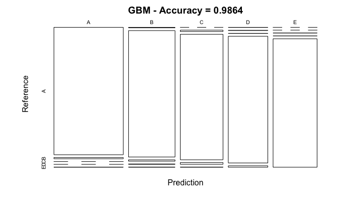

```r
# plot matrix results
plot(confMatGBM$table, col = confMatGBM$byClass,
     main = paste("GBM - Accuracy =", round(confMatGBM$overall['Accuracy'], 4)))
```

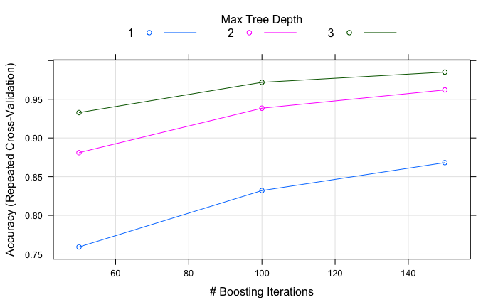

```r
plot(modFitGBM)
```

# Applying model to testing data.

This is necessary in order to get the quiz. In this particular case, I’ll use the Randorm forrest model due to better accuracy.

```r
predictTEST <- predict(modFitRandForest, newdata=testing)
predictTEST
```

```
 [1] B A B A A E D B A A B C B A E E A B B B
Levels: A B C D E
```